# Red Wine Quality Exploration

Holly Moore

30 August, 2020

The dataset used in this exploration contains 1,599 red wines. It has 11 variables on the chemical properties of the wines. A minimum of three wine experts rated the quality of each wine, and they provided a rating between 0 and 10 (0 being very bad, and 10 excellent). We will explore which chemical properties influence the quality of red wines.

# 1 Univariated Plots Section

```
## [1] 1599   13
```

```
## 'data.frame':    1599 obs. of  13 variables:
##  $ X                   : int  1 2 3 4 5 6 7 8 9 10 ...
##  $ fixed.acidity       : num  7.4 7.8 7.8 11.2 7.4 7.4 7.9 7.3 7.8 7.5 ...
##  $ volatile.acidity    : num  0.7 0.88 0.76 0.28 0.7 0.66 0.6 0.65 0.58 0.5 ...
##  $ citric.acid         : num  0 0 0.04 0.56 0 0 0.06 0 0.02 0.36 ...
##  $ residual.sugar      : num  1.9 2.6 2.3 1.9 1.9 1.8 1.6 1.2 2 6.1 ...
##  $ chlorides           : num  0.076 0.098 0.092 0.075 0.076 0.075 0.069 0.065 0.073 0.071 ...
##  $ free.sulfur.dioxide : num  11 25 15 17 11 13 15 15 9 17 ...
##  $ total.sulfur.dioxide: num  34 67 54 60 34 40 59 21 18 102 ...
##  $ density             : num  0.998 0.997 0.997 0.998 0.998 ...
##  $ pH                  : num  3.51 3.2 3.26 3.16 3.51 3.51 3.3 3.39 3.36 3.35 ...
##  $ sulphates           : num  0.56 0.68 0.65 0.58 0.56 0.56 0.46 0.47 0.57 0.8 ...
##  $ alcohol             : num  9.4 9.8 9.8 9.8 9.4 9.4 9.4 10 9.5 10.5 ...
##  $ quality             : int  5 5 5 6 5 5 5 7 7 5 ...
```

Above, struture of the dataset

```
##        X          fixed.acidity   volatile.acidity  citric.acid
##  Min.   :   1.0   Min.   : 4.60   Min.   :0.1200   Min.   :0.000
##  1st Qu.: 400.5   1st Qu.: 7.10   1st Qu.:0.3900   1st Qu.:0.090
##  Median : 800.0   Median : 7.90   Median :0.5200   Median :0.260
##  Mean   : 800.0   Mean   : 8.32   Mean   :0.5278   Mean   :0.271
##  3rd Qu.:1199.5   3rd Qu.: 9.20   3rd Qu.:0.6400   3rd Qu.:0.420
##  Max.   :1599.0   Max.   :15.90   Max.   :1.5800   Max.   :1.000
##  residual.sugar     chlorides       free.sulfur.dioxide total.sulfur.dioxide
##  Min.   : 0.900   Min.   :0.01200   Min.   : 1.00       Min.   :  6.00
##  1st Qu.: 1.900   1st Qu.:0.07000   1st Qu.: 7.00       1st Qu.: 22.00
##  Median : 2.200   Median :0.07900   Median :14.00       Median : 38.00
##  Mean   : 2.539   Mean   :0.08747   Mean   :15.87       Mean   : 46.47
##  3rd Qu.: 2.600   3rd Qu.:0.09000   3rd Qu.:21.00       3rd Qu.: 62.00
##  Max.   :15.500   Max.   :0.61100   Max.   :72.00       Max.   :289.00
##     density             pH          sulphates         alcohol
##  Min.   :0.9901   Min.   :2.740   Min.   :0.3300   Min.   : 8.40
##  1st Qu.:0.9956   1st Qu.:3.210   1st Qu.:0.5500   1st Qu.: 9.50
##  Median :0.9968   Median :3.310   Median :0.6200   Median :10.20
##  Mean   :0.9967   Mean   :3.311   Mean   :0.6581   Mean   :10.42
##  3rd Qu.:0.9978   3rd Qu.:3.400   3rd Qu.:0.7300   3rd Qu.:11.10
##  Max.   :1.0037   Max.   :4.010   Max.   :2.0000   Max.   :14.90
##     quality
##  Min.   :3.000
##  1st Qu.:5.000
##  Median :6.000
##  Mean   :5.636
##  3rd Qu.:6.000
##  Max.   :8.000
```

Above: summary of the dataset. The dataset contains 1599 rows and 13 columns. The first column labeled ‘X’ is simply row numbers, and I have chosen to exclude it from our dataset.

```
##  [1] "fixed.acidity"        "volatile.acidity"     "citric.acid"
##  [4] "residual.sugar"       "chlorides"            "free.sulfur.dioxide"
##  [7] "total.sulfur.dioxide" "density"              "pH"
## [10] "sulphates"            "alcohol"              "quality"
```

That leaves us with 12 variables to explore and 1599 observations.

## 1.1 Plot variables

### 1.1.1 Acidity Levels (Fixed, Volatile, & Citric)

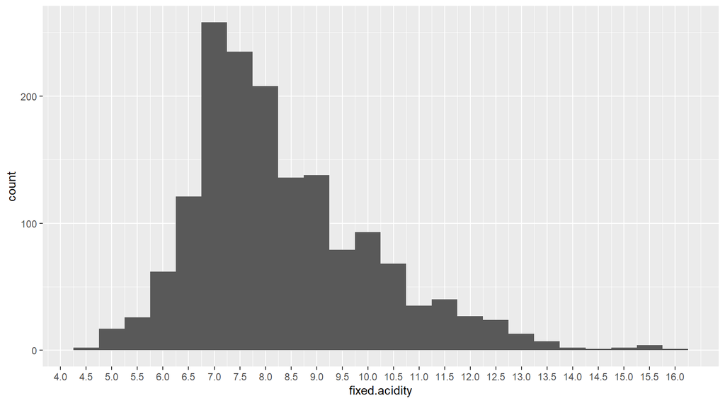

```
##    Min. 1st Qu.  Median    Mean 3rd Qu.    Max.
##    4.60    7.10    7.90    8.32    9.20   15.90
```

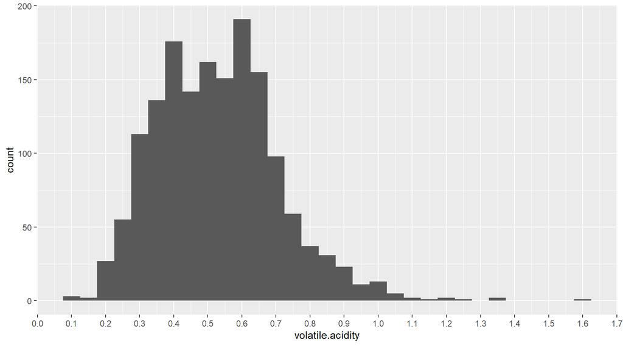

```
##    Min. 1st Qu.  Median    Mean 3rd Qu.    Max.
##  0.1200  0.3900  0.5200  0.5278  0.6400  1.5800
```

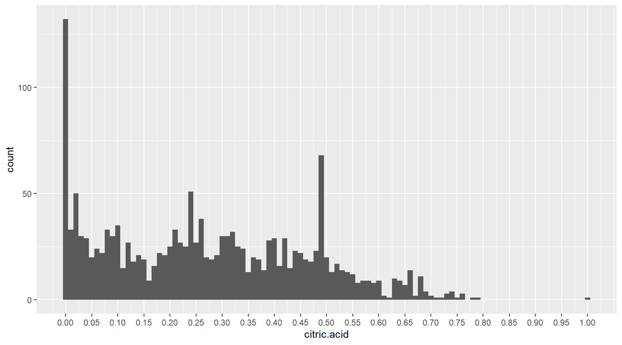

```
##    Min. 1st Qu.  Median    Mean 3rd Qu.    Max.
##   0.000   0.090   0.260   0.271   0.420   1.000
```

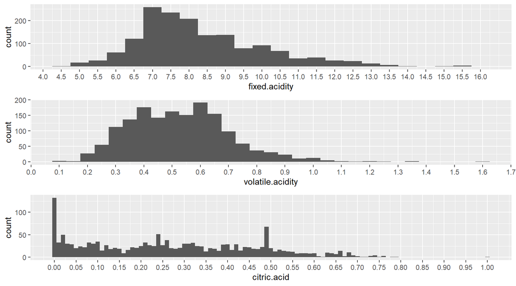

Looking at the acidity levels…

Fixed acidity ranges from 4.6 to 15.9. It has a reasonably normal distribution, skewed slightly right, with a median 7.9 and mean of 8.32.

Volatile acidity ranges from .12 to 1.58. The distribution is also fairly normal, would be considered bimodal with peaks at 0.4 and 0.6, and slightly skewed right. The median and the mean are almost the same (median 0.52, mean 0.5278).

### 1.1.2 Residual Sugar Level

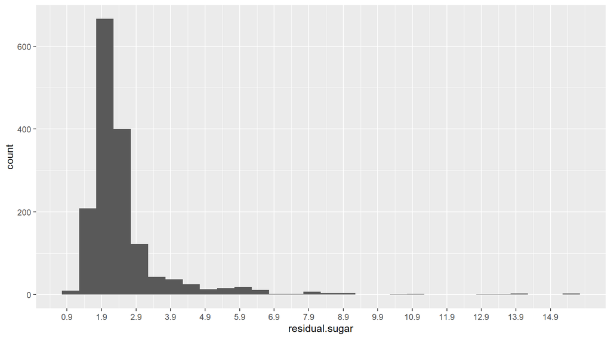

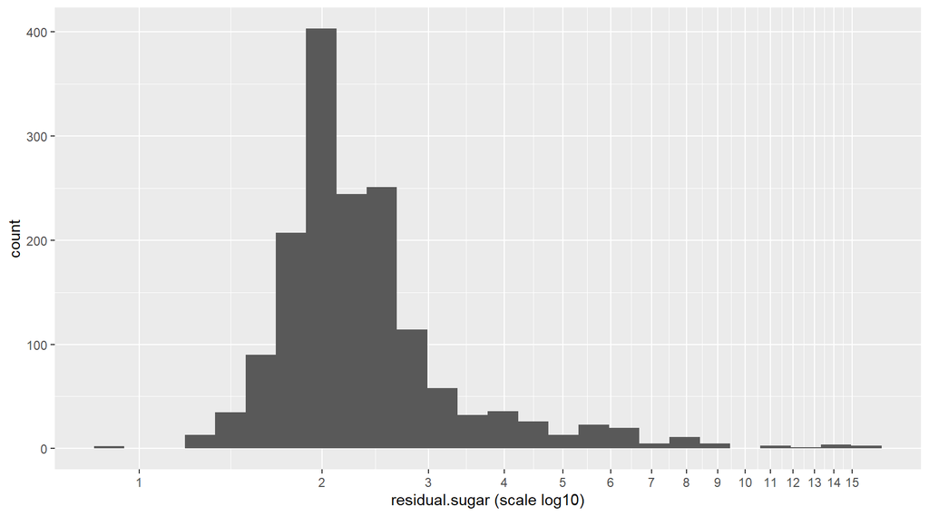

```
##    Min. 1st Qu.  Median    Mean 3rd Qu.    Max.
##   0.900   1.900   2.200   2.539   2.600  15.500
```

Residual sugar levels range from 0.9 to 15.5, with a median 2.2 and a mean of 2.539. The distribution is heavily skewed right, with most observations falling under 3. Since we have a very long tail, the bottom graph is transformed using a log scale 10 on the x-axis to get a better look.

### 1.1.3 Chloride level

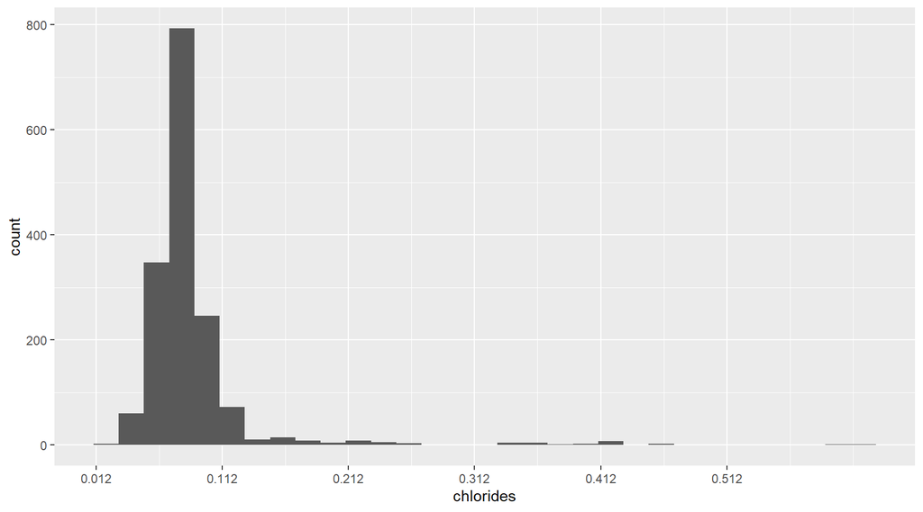

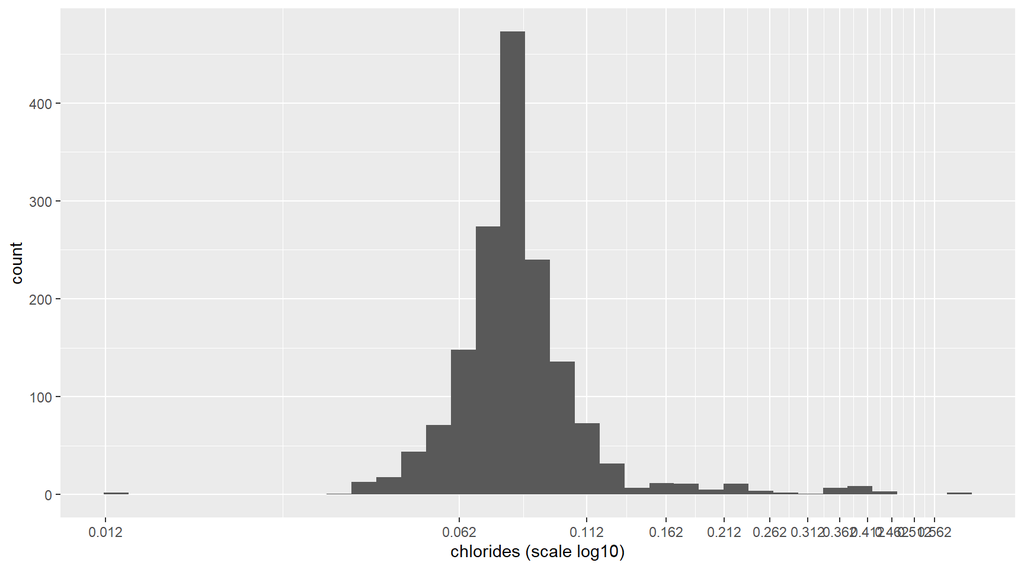

```
##    Min. 1st Qu.  Median    Mean 3rd Qu.    Max.
## 0.01200 0.07000 0.07900 0.08747 0.09000 0.61100
```

### 1.1.4 Free Sulfur Dioxide Levels

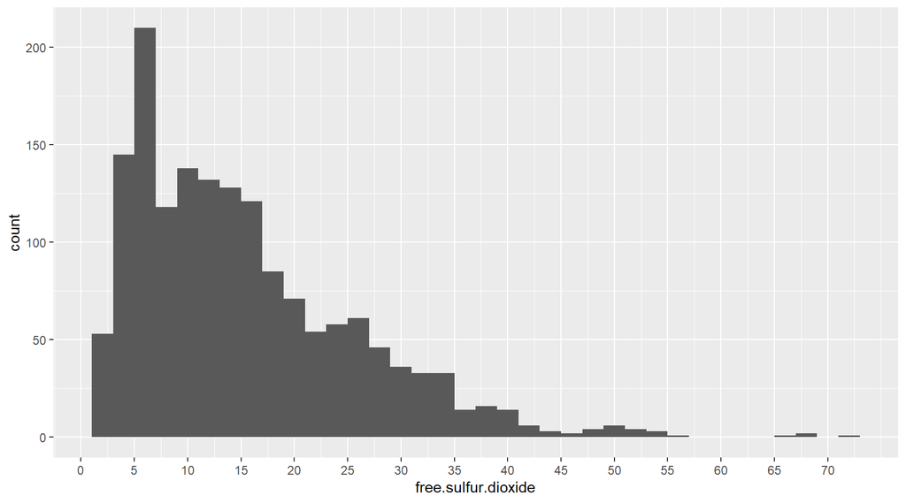

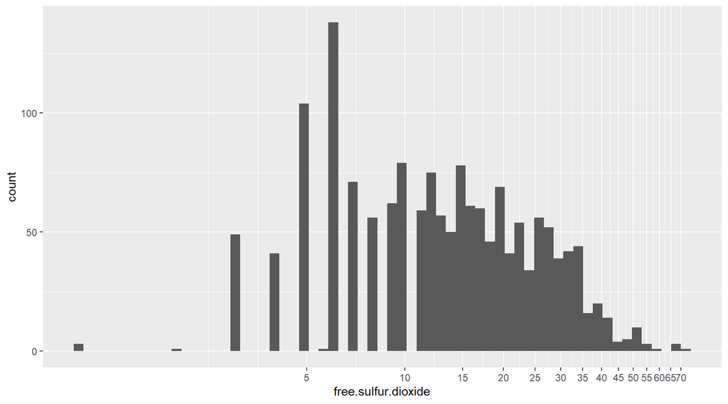

```
##    Min. 1st Qu.  Median    Mean 3rd Qu.    Max.
##    1.00    7.00   14.00   15.87   21.00   72.00
```

```
##
##    1    2    3    4    5  5.5    6    7    8    9   10   11   12   13   14   15
##    3    1   49   41  104    1  138   71   56   62   79   59   75   57   50   78
##   16   17   18   19   20   21   22   23   24   25   26   27   28   29   30   31
##   61   60   46   39   30   41   22   32   34   24   32   29   23   23   16   20
##   32   33   34   35   36   37 37.5   38   39   40 40.5   41   42   43   45   46
##   22   11   18   15   11    3    2    9    5    6    1    7    3    3    3    1
##   47   48   50   51   52   53   54   55   57   66   68   72
##    1    4    2    4    3    1    1    2    1    1    2    1
```

Free sulfur dioxide has a wide range from 1 to 72, but 75% of observations fall at 21 and below. The median is 14, and the median is 15.87. The distribution is heavily skewed right like many of the other variables we have looked at. Due to the long tail, logscale was used on the x-axis, allowing us to see a sharp peak 6. After seeing the peak at 6, I ran the table command so we could see how many of each number we were dealing with. There are 138 observations with number 6.

### 1.1.5 Total Sulfur Dioxide Levels

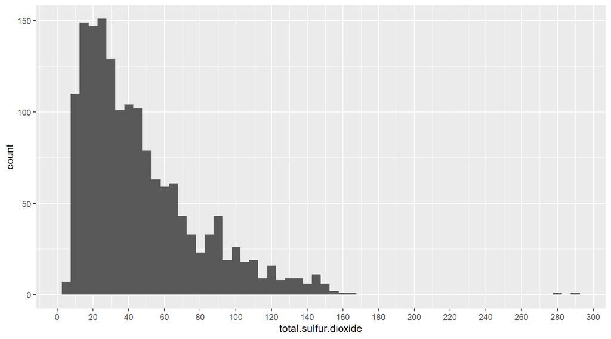

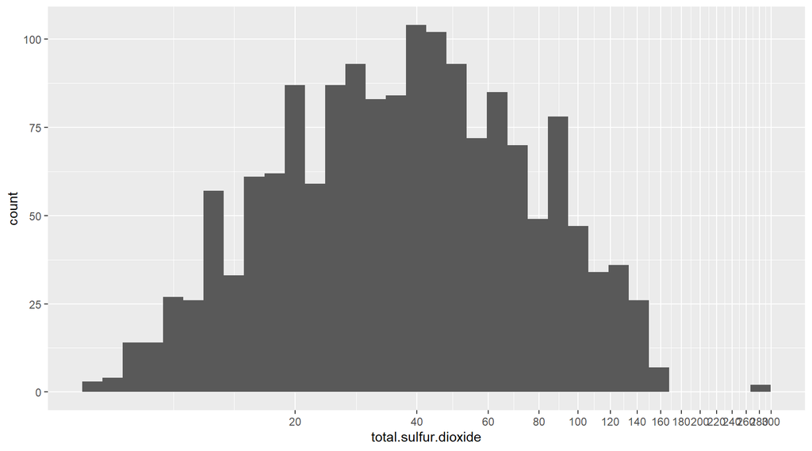

```
##    Min. 1st Qu.  Median    Mean 3rd Qu.    Max.
##    6.00   22.00   38.00   46.47   62.00  289.00
```

Total sulfur dioxide has an even wider range, from 6 to 289, but 75% of observations fall at 62 and below. The median is 38, and the median is 46.47. The distribution is heavily skewed right. We used logscale to transform the x-axis, giving us a better look at the data. The transformed data has a normal distribution peaking between 40-50.

### 1.1.6 Density

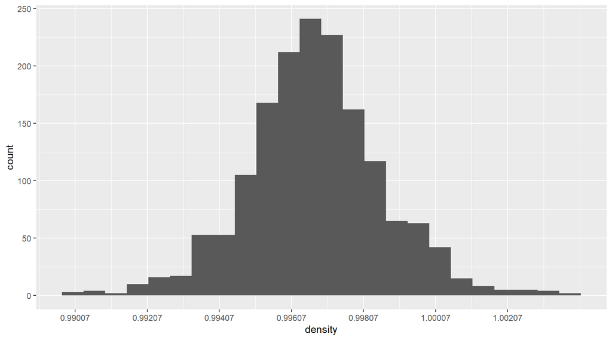

```
##    Min. 1st Qu.  Median    Mean 3rd Qu.    Max.
##  0.9901  0.9956  0.9968  0.9967  0.9978  1.0037
```

### 1.1.7 pH Levels

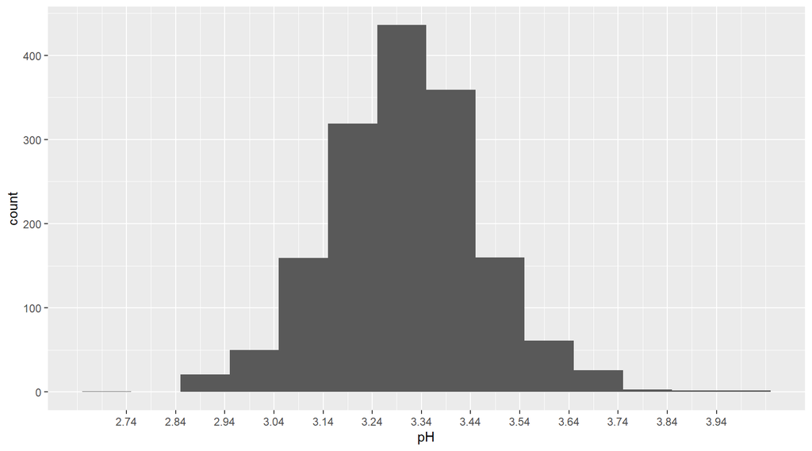

```
##    Min. 1st Qu.  Median    Mean 3rd Qu.    Max.
##   2.740   3.210   3.310   3.311   3.400   4.010
```

The pH levels also have a small variance range, from 2.74 to 4.01 (difference of 1.27). The distribution is normal, almost symmetrical, with the median and the mean being almost the same (median 3.310 & mean 3.311).

### 1.1.8 Sulphate Levels

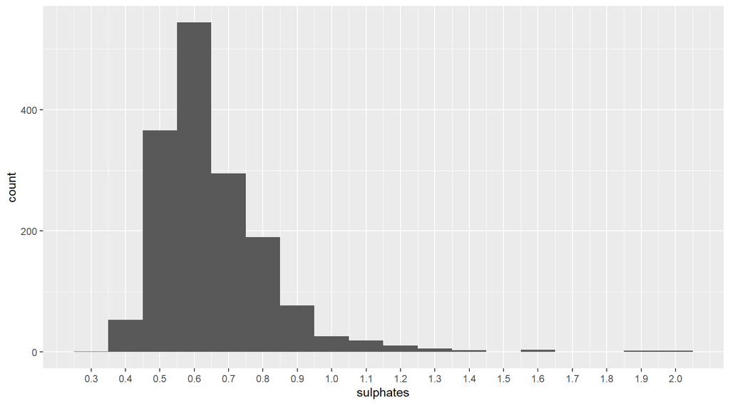

```
##    Min. 1st Qu.  Median    Mean 3rd Qu.    Max.
##  0.3300  0.5500  0.6200  0.6581  0.7300  2.0000
```

### 1.1.9 Alcohol Level

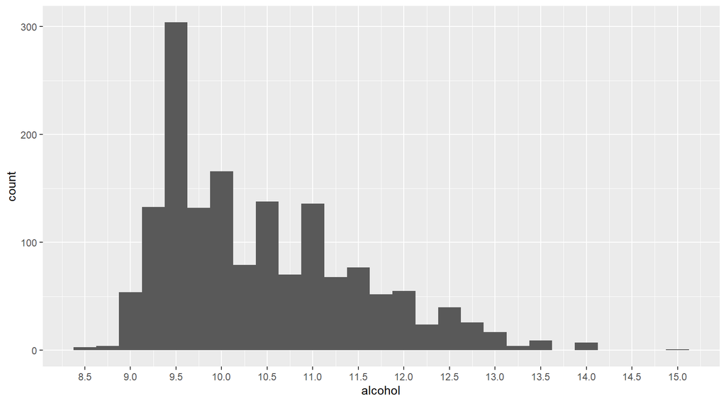

```
##    Min. 1st Qu.  Median    Mean 3rd Qu.    Max.
##    8.40    9.50   10.20   10.42   11.10   14.90
```

The alcohol level ranges from 8.4 to 14.9. The mean and the median are almost the same (median 10.2, mean 10.42). The distribution is right-skewed with the peak at 9.5. The highest rating of 14.9 looks like an outliner.

### 1.1.10 Quality Ratings

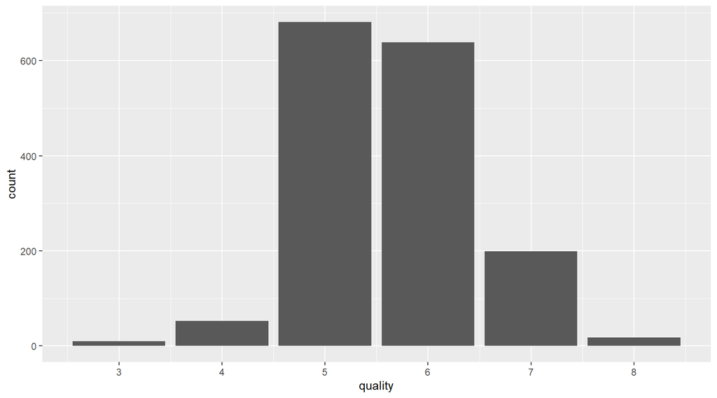

```
##    Min. 1st Qu.  Median    Mean 3rd Qu.    Max.
##   3.000   5.000   6.000   5.636   6.000   8.000
```

```
##
##   3   4   5   6   7   8
##  10  53 681 638 199  18
```

The quality rating scale goes from 0 to 10, with 10 being the best. However, in this dataset, our ratings go from 3 to 8 (8 being the best). The distribution is normal, peaking between five & six. Most of the observations are between 5 & 7.

# 2 Univariate Analysis

### 2.0.1 What is the structure of your dataset?

This dataset contains 1,599 observations and has twelve variables (11 of which are chemical properties of the wines). The variables are: fixed.acidity, volatile.acidity, citric.acid, residual.sugar, chlorides, free.sulfur.dioxide, total.sulfur.dioxide, density, pH, sulphates, alcohol, and quality.

### 2.0.2 What is/are the main feature(s) of interest in your dataset?

The main item of interest is wine quality. We are exploring the chemical properties to determine which ones influence the quality of red wines.

### 2.0.3 What other features in the dataset do you think will help support your

investigation into your feature(s) of interest?

Since we are interested in red wine quality, we want to locate the variables that affect quality. Right now, I am interested in the variables that correlate with quality.

### 2.0.4 Did you create any new variables from existing variables in the dataset?

No.

### 2.0.5 Of the features you investigated, were there any unusual distributions?

Did you perform any operations on the data to tidy, adjust, or change the form of the data? If so, why did you do this?

The dataset came nice and tidy. While making the initial variable plots, adjusting the bin size was about all that needed to be done. And four of the variables (residual.sugar, chlorides, free.sulfur.dioxide, total.sulfur.dioxide) had long tails. In order to zoom in and get a better picture of the distribution, I used scale_x_log10 on the x-axis to transform the data.

# 3 Bivariate Plots Section

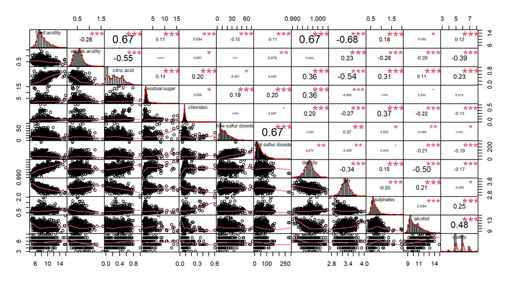

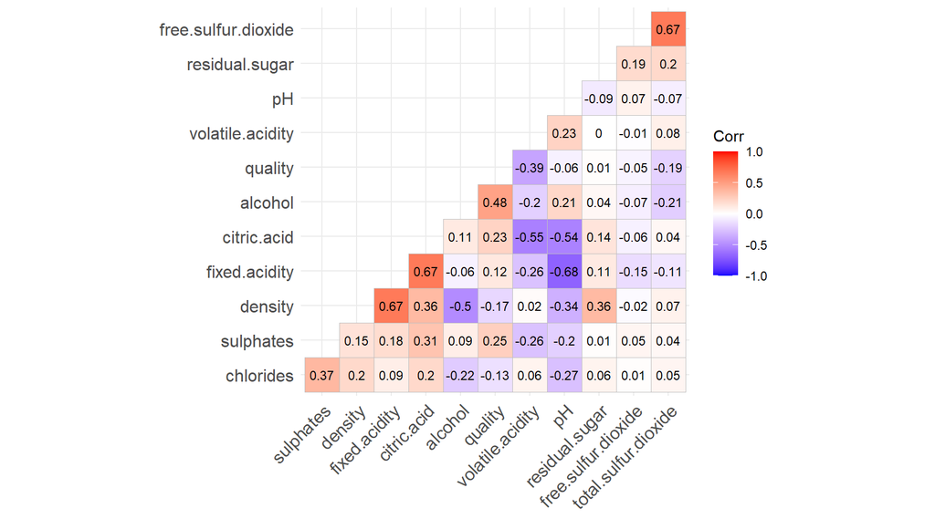

Above, we have two different correlation matrix plots. They make it easy to see the strength of the relationships between the variables.

In the first matrix plot, the higher the correlation, the bigger the font used for the correlation strength.  
For fun, I threw in the second matrix plot. In this matrix, the strength of the relationship is represented by color, the darker the shade (either red or purple), the stronger the relationship.

**Correlations with Quality**  
Although some of these correlations are relatively weak, they are still listed here. Variables with the strongest correlation to quality are:  
0.48 alcohol  
-0.39 volatile acidity  
0.25 sulphates  
0.23 citric.acid

As for the relationships between the other supporting variables, there are quite a few interesting correlations we can see (both positive and negative).

**Negative correlations**  
-0.68 pH vs. fixed.acidity  
-0.55 volatile.acidity vs. citric.acid  
-0.54 pH vs. citric.acid  
-0.50 alcohol vs. density

**Positive correlations**  
0.67 fixed.acidity vs. citric.acid  
0.67 fixed.acidity vs. density  
0.67 total.sulfur.dioxide vs. free.sulfure.dioxide  
0.37 sulphates vs. chlorides  
0.36 residual.sugar vs. density

I am surprised to see only a few variables correlate to wine quality, I expected more. However, there are still plenty of correlations to explore.

Now we will plot some of the correlations!

## 3.1 Negative Correlations

### 3.1.1 pH vs. Fixed Acidity

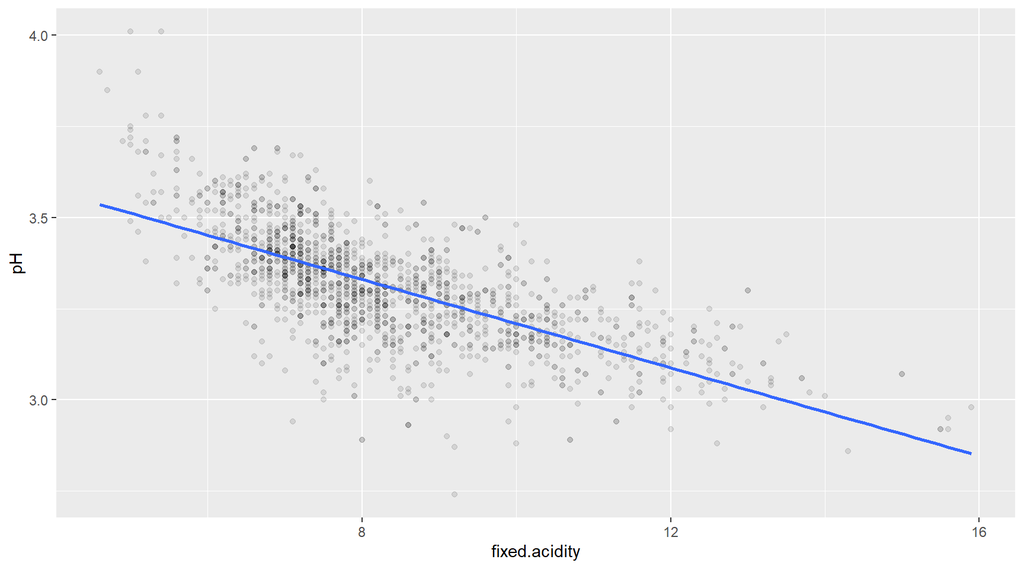

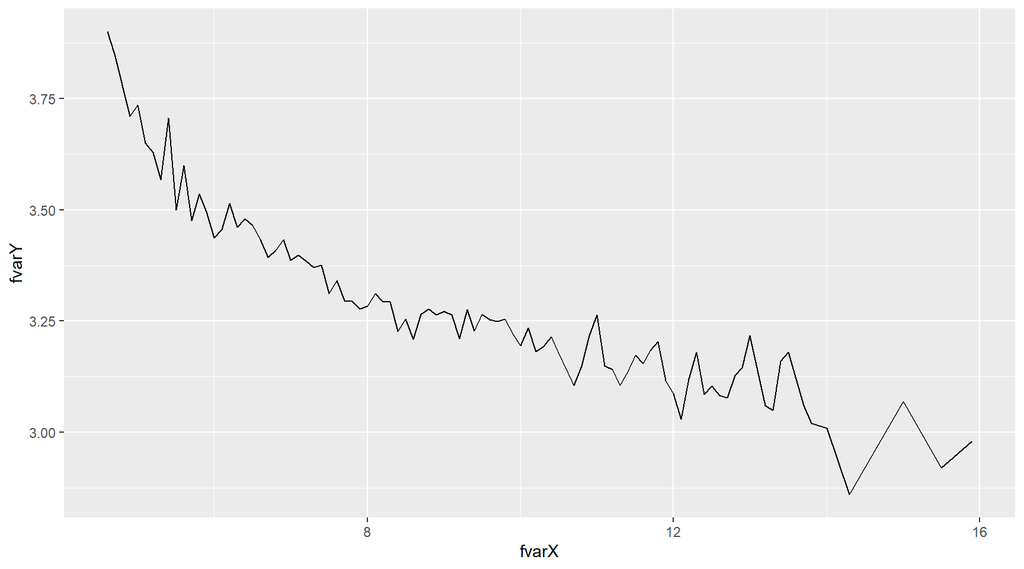

```
##
##  Pearson's product-moment correlation
##
## data:  pf$pH and pf$fixed.acidity
## t = -37.366, df = 1597, p-value < 2.2e-16
## alternative hypothesis: true correlation is not equal to 0
## 95 percent confidence interval:
##  -0.7082857 -0.6559174
## sample estimates:
##        cor
## -0.6829782
```

```
##    Min. 1st Qu.  Median    Mean 3rd Qu.    Max.
##   2.740   3.210   3.310   3.311   3.400   4.010
```

```
##    Min. 1st Qu.  Median    Mean 3rd Qu.    Max.
##    4.60    7.10    7.90    8.32    9.20   15.90
```

The variables pH and fixed acidity have the highest negative correlation of all the variables (corr -0.68). The plot shows that as pH increases, the level of fixed acidity decreases. We made a point and line plot, both are interesting to look at.

### 3.1.2 Volatile Acidity vs. Citric Acid

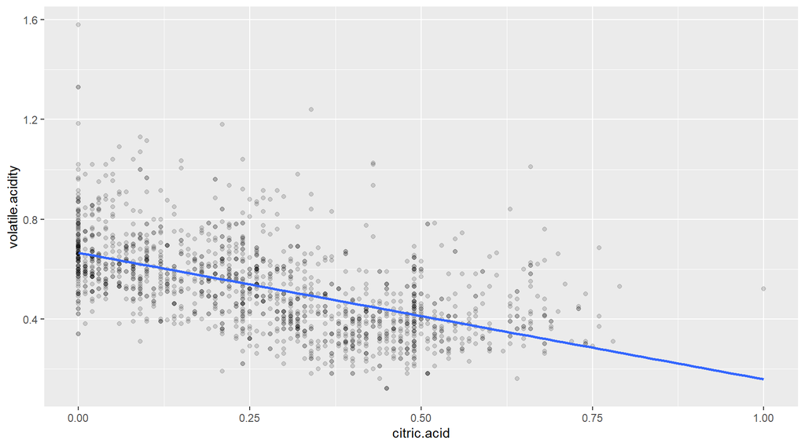

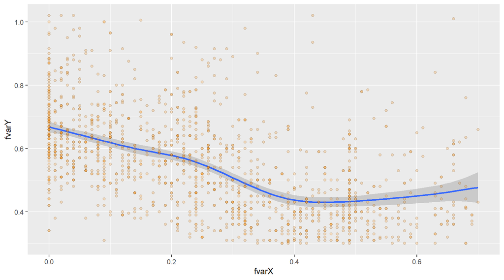

```
##
##  Pearson's product-moment correlation
##
## data:  pf$volatile.acidity and pf$citric.acid
## t = -26.489, df = 1597, p-value < 2.2e-16
## alternative hypothesis: true correlation is not equal to 0
## 95 percent confidence interval:
##  -0.5856550 -0.5174902
## sample estimates:
##        cor
## -0.5524957
```

```
##    Min. 1st Qu.  Median    Mean 3rd Qu.    Max.
##  0.1200  0.3900  0.5200  0.5278  0.6400  1.5800
```

```
##    Min. 1st Qu.  Median    Mean 3rd Qu.    Max.
##   0.000   0.090   0.260   0.271   0.420   1.000
```

These two variables, volatile acidity and citric acid, have the 2nd highest negative correlation (corr -0.55). So, it is not surprising that the plot looks similar to the previous one. As volatile acidity increases, citric acid decreases. On the second plot, we removed the outliners to get a better view of the distribution.

### 3.1.3 pH vs. Citric Acid

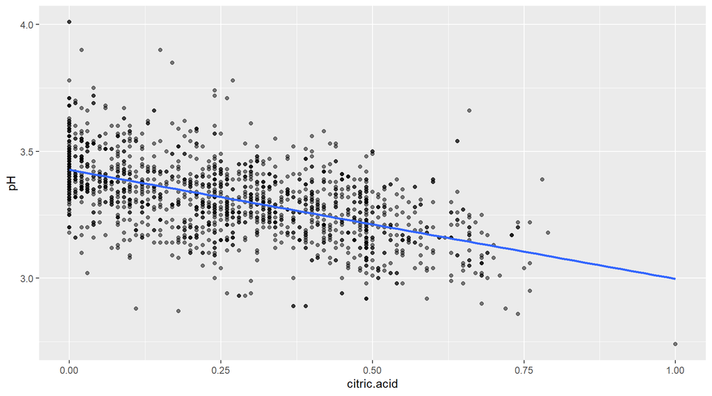

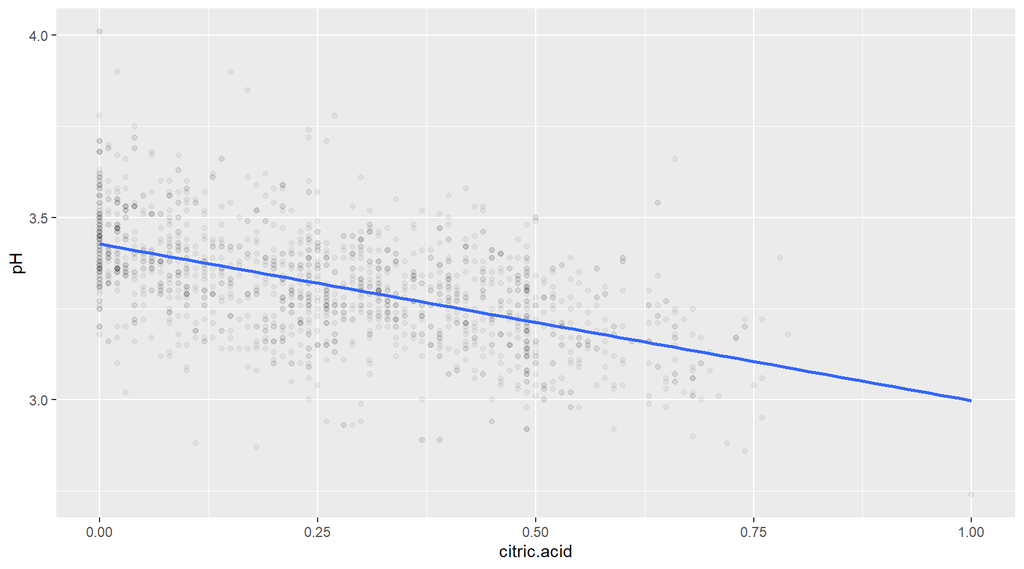

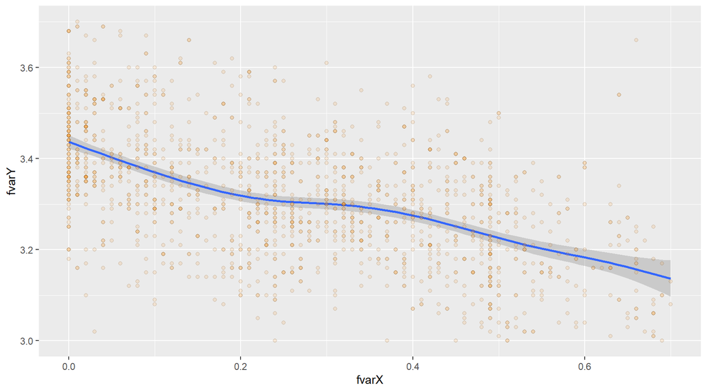

```
##    Min. 1st Qu.  Median    Mean 3rd Qu.    Max.
##   0.000   0.090   0.260   0.271   0.420   1.000
```

```
##    Min. 1st Qu.  Median    Mean 3rd Qu.    Max.
##   2.740   3.210   3.310   3.311   3.400   4.010
```

```
##
##  Pearson's product-moment correlation
##
## data:  pf$pH and pf$citric.acid
## t = -25.767, df = 1597, p-value < 2.2e-16
## alternative hypothesis: true correlation is not equal to 0
## 95 percent confidence interval:
##  -0.5756337 -0.5063336
## sample estimates:
##        cor
## -0.5419041
```

Above is the last negative correlation we will do for variables outside of quality. Again, as citric acid increases, pH decreases (corr -0.54). We do have an outliner at 1. I made two different plots, one with alpha at .5 and the other with alpha at .05. The plot with .05 makes it easy to see where we have spikes of citric acid. On the final plot, we limited the range, allowing us a better view of the distribution.

## 3.2 Positive correlations

### 3.2.1 Fixed Acidity and Density

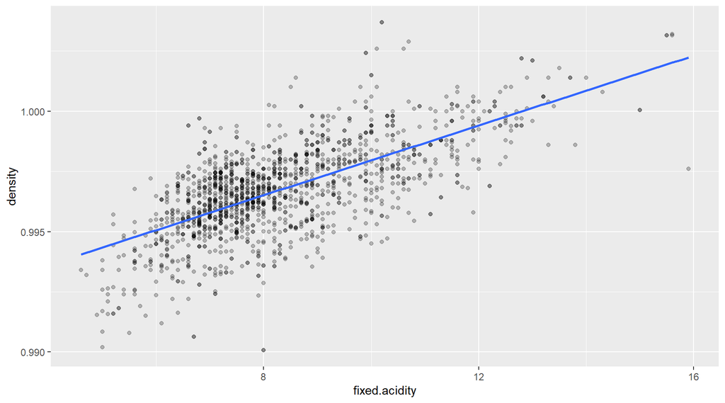

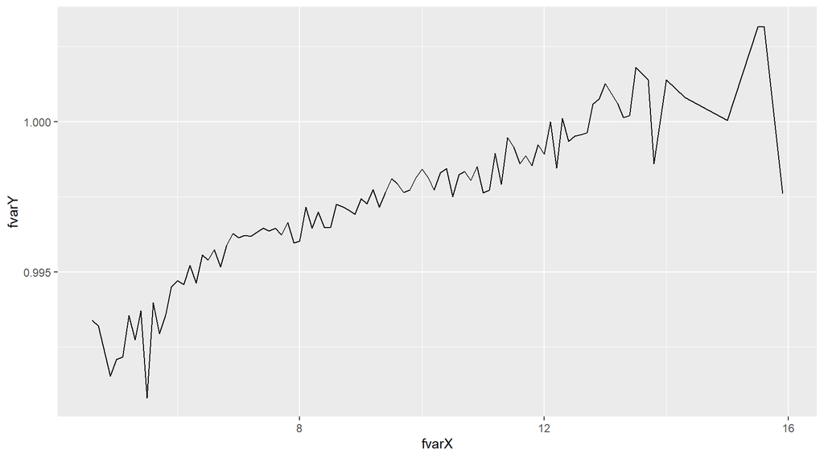

```
##    Min. 1st Qu.  Median    Mean 3rd Qu.    Max.
##  0.9901  0.9956  0.9968  0.9967  0.9978  1.0037
```

```
##    Min. 1st Qu.  Median    Mean 3rd Qu.    Max.
##    4.60    7.10    7.90    8.32    9.20   15.90
```

```
##
##  Pearson's product-moment correlation
##
## data:  pf$density and pf$fixed.acidity
## t = 35.877, df = 1597, p-value < 2.2e-16
## alternative hypothesis: true correlation is not equal to 0
## 95 percent confidence interval:
##  0.6399847 0.6943302
## sample estimates:
##       cor
## 0.6680473
```

Above is the first positive correlation we have explored (corr is .67). Making it clear to see that as fixed acidity increases, so does density. The line chart does a nice job of showing the positive pattern, while pointing out the outliners.

### 3.2.2 Free Sulfer Dioxide vs Total Sulfer Dioxide

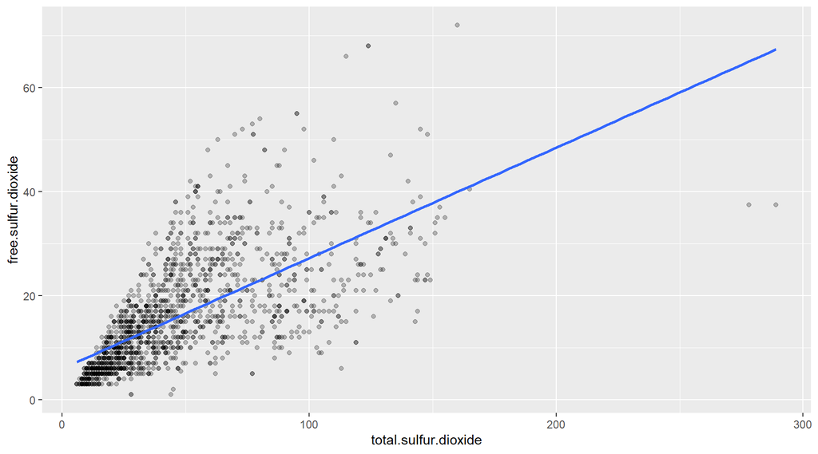

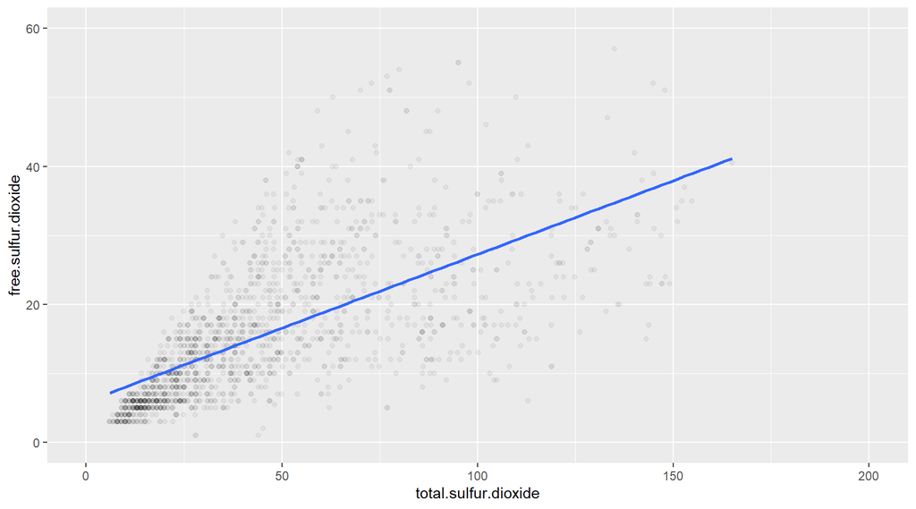

```
##
##  Pearson's product-moment correlation
##
## data:  pf$free.sulfur.dioxide and pf$total.sulfur.dioxide
## t = 35.84, df = 1597, p-value < 2.2e-16
## alternative hypothesis: true correlation is not equal to 0
## 95 percent confidence interval:
##  0.6395786 0.6939740
## sample estimates:
##       cor
## 0.6676665
```

```
##    Min. 1st Qu.  Median    Mean 3rd Qu.    Max.
##    1.00    7.00   14.00   15.87   21.00   72.00
```

```
##    Min. 1st Qu.  Median    Mean 3rd Qu.    Max.
##    6.00   22.00   38.00   46.47   62.00  289.00
```

The above plot is funny; it looks like a megaphone. These two variables have a strong correlation (.67), in a three-way tie for the strongest positive correlation in this dataset. Since they are both a form of sulfur dioxide, it is not surprising they have a strong correlation. The second plot limits both the x an y axis, giving us a better view of the distribution.

## 3.3 Correlations with Quality!

### 3.3.1 Quality vs Alcohol

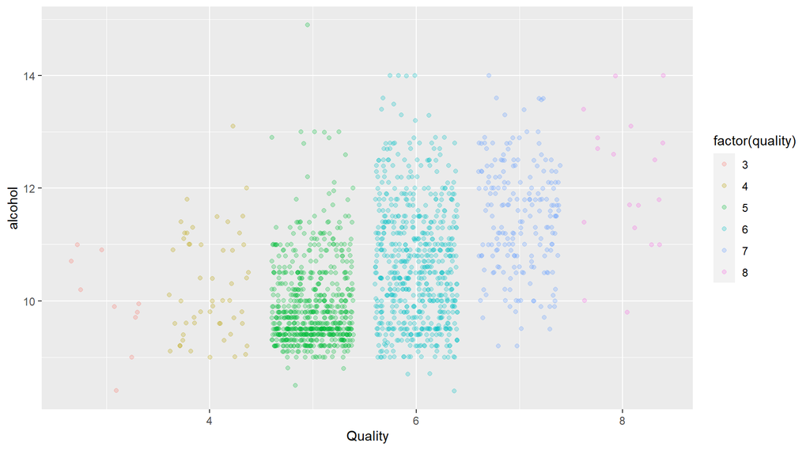

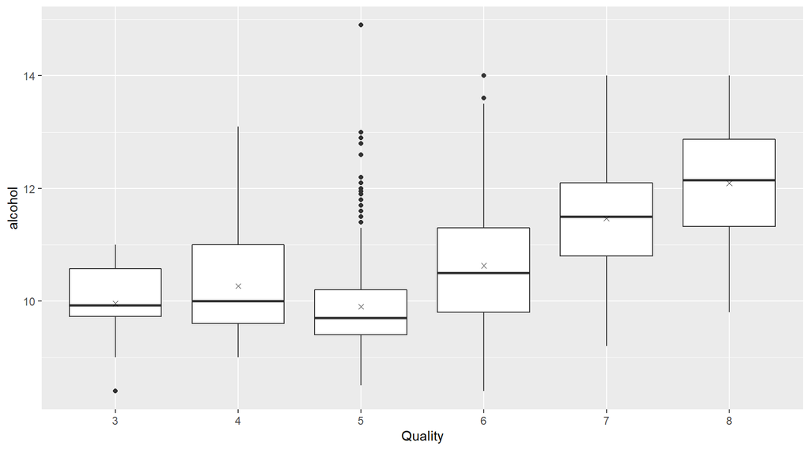

```
##
##  Pearson's product-moment correlation
##
## data:  pf$alcohol and pf$quality
## t = 21.639, df = 1597, p-value < 2.2e-16
## alternative hypothesis: true correlation is not equal to 0
## 95 percent confidence interval:
##  0.4373540 0.5132081
## sample estimates:
##       cor
## 0.4761663
```

```
## [1] "alcohol summary"
```

```
##    Min. 1st Qu.  Median    Mean 3rd Qu.    Max.
##    8.40    9.50   10.20   10.42   11.10   14.90
```

```
## pf$quality: 3
##    Min. 1st Qu.  Median    Mean 3rd Qu.    Max.
##   8.400   9.725   9.925   9.955  10.575  11.000
## ------------------------------------------------------------
## pf$quality: 4
##    Min. 1st Qu.  Median    Mean 3rd Qu.    Max.
##    9.00    9.60   10.00   10.27   11.00   13.10
## ------------------------------------------------------------
## pf$quality: 5
##    Min. 1st Qu.  Median    Mean 3rd Qu.    Max.
##     8.5     9.4     9.7     9.9    10.2    14.9
## ------------------------------------------------------------
## pf$quality: 6
##    Min. 1st Qu.  Median    Mean 3rd Qu.    Max.
##    8.40    9.80   10.50   10.63   11.30   14.00
## ------------------------------------------------------------
## pf$quality: 7
##    Min. 1st Qu.  Median    Mean 3rd Qu.    Max.
##    9.20   10.80   11.50   11.47   12.10   14.00
## ------------------------------------------------------------
## pf$quality: 8
##    Min. 1st Qu.  Median    Mean 3rd Qu.    Max.
##    9.80   11.32   12.15   12.09   12.88   14.00
```

We are finally looking at the correlations with quality. This is interesting, but not surprising. The level of alcohol correlates with red wine quality at 0.48. Looking at these plots, you can see the gradual increase in quality as alcohol level increases. It is fun to look at these different plots; the boxplot especially does a great job visualizing the positive correlation. I do notice a slight decrease in alcohol level in the wine rated quality level 5. I do wonder what caused this decrease?